# week16

b06208016楊鎧綾

December 28, 2018

## 16.8

### a

$H_0:$ no mattter what age it is the number of children couple average wants is the same  
$\mu_1=\mu_2=\mu_3=\mu_4$  
$H_a:$ the number of children couple wants is different according to age  
$\mu_1\neq\mu_2\neq\mu_3\neq\mu_4$ (at least one of them is different from others)  
$\mu$ means the ideal number of children a couple want, and the age range is 18~29, 30~44, 45~59, 60~89, respectively  
the sample is from US adults from age 18~89, so the population it can infer might be US adults from age 18~89, better not overestimate

### b

F-statistic: 7.41; p-value: 0  
under the confidence level of 95% $\alpha=0.05$, the p-value=0 is smaller than $\alpha$, so we can reject the null hypothesis,  
we can say that the number of children couple wants is different according to age

### c

從信賴區間我們可以看到18-29歲及60-89歲的信賴區間大量重疊，而30-44歲及45-59歲的也大量重疊，前兩組的信賴區間高於後兩組，而且他們並無重疊  
我們可以說18-29歲及60-89歲是無差別的，30-44歲及45-59歲的也是無差別的，但是18-29歲及60-89歲想要的孩子較多，他們與30-44歲及45-59歲是有差別的

### d

```r
0.8198*2>0.9903
```

```
## [1] TRUE
```

the max standard deviation is smaller than two times of min sd, so it is reasonable to assume equal sd

## 16.24

### a

```r
d1=c(7,2,5,6)
d2=c(8,12,0,4)
d3=c(16,9,5,10)
x1=mean(d1)
x2=mean(d2)
x3=mean(d3)
xbar=(x1+x2+x3)/3
xbar;x1;x2;x3
```

```
## [1] 7
```

```
## [1] 5
```

```
## [1] 6
```

```
## [1] 10
```

xbar=7; x1=5; x2=6; x3=10

### b

```r
ssg=length(d1)*(x1-xbar)^2+length(d2)*(x2-xbar)^2+length(d3)*(x3-xbar)^2
ssg
```

```
## [1] 56
```

SS Group = 56

### c

```r
all=c(d1,d2,d3)
sst=0
for (i in all){
  sst=sst+((i-xbar)^2)
}
sst
```

```
## [1] 212
```

SS Total=212

### d

```r
sse=sst-ssg
sse
```

```
## [1] 156
```

SS Error = 156

### e

```r
msg=ssg/(3-1)
mse=sse/(length(all)-3)
f_score=msg/mse;f_score
```

```
## [1] 1.615385
```

the f-statistic is 1.615, and the degree of freedom is 2 and 9

## 16.36

### a

男生坐越前面睡越少，坐越後面則睡越多，而且睡覺時數差異頗大

### b

女生坐越前面睡越多，坐越後面則睡越少，但睡覺時數差異不大

### c

因為兩條線沒有平行，所以可以說性別與座位有交互作用，所坐座位對於不同性別來說影響到平均睡眠時間程度不一

## 16.52

### a

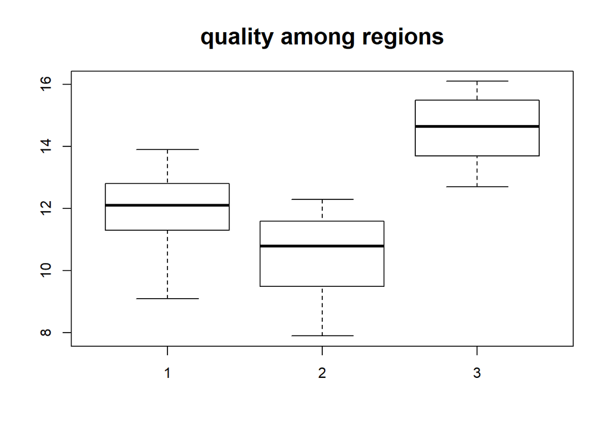

```r
load("wineratings.rdata")
# data distribution
boxplot(q ~ r, data = wineratings,
        main = "quality among regions", cex.main = 1.6)

#install.packages("ggpubr")
library(ggpubr)
```

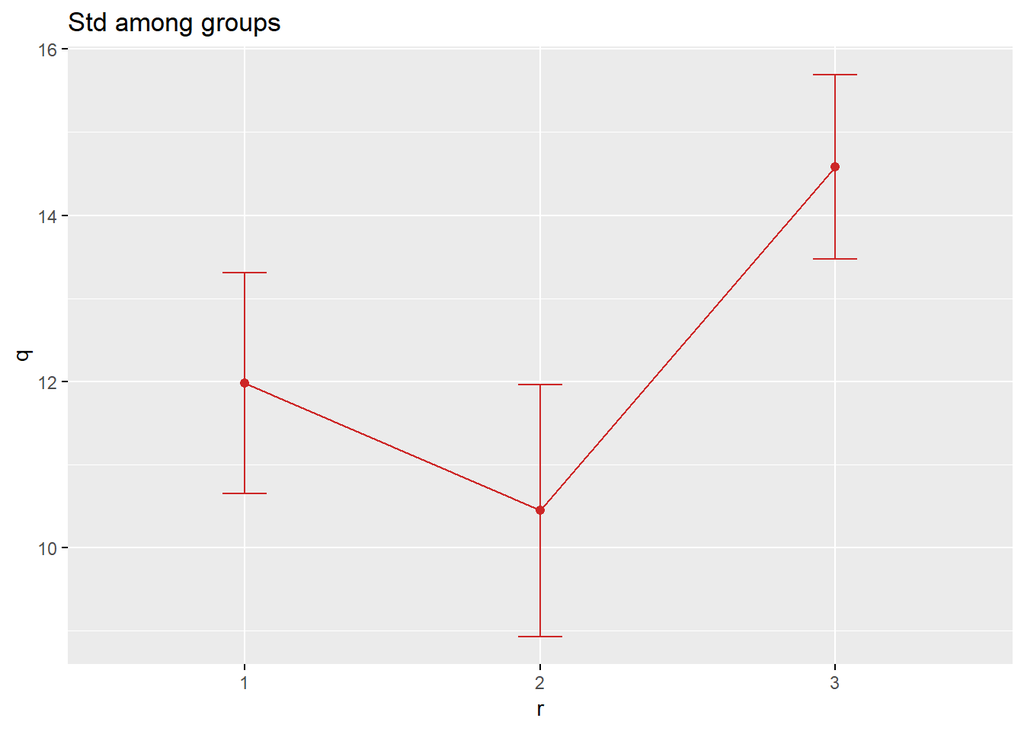

```r
# visualize std for each group
ggline(wineratings, x = "r", y = "q", add = c("mean_sd"),
       color = "firebrick3", main = "Std among groups",
       ggtheme = theme_gray())
```

the data of region 3 is higher than other two, the quality of region 3 is different from the other two, and region 1 and two might be no difference

### b

```r
# mean and sd for each group
stu.mean = tapply(wineratings$q, wineratings$r, mean)
stu.sd = tapply(wineratings$q, wineratings$r, sd)
stu.n = tapply(wineratings$q, wineratings$r, length)

stu = data.frame(n = stu.n, mean = stu.mean, sd = stu.sd)
stu
```

```
##    n     mean       sd
## 1 17 11.97647 1.327841
## 2  9 10.44444 1.515017
## 3 12 14.58333 1.111783
```

the mean and sd is as the dataframe shows

### c

step.1  
$H_0:$ there are no difference between regions, that is $\mu_1 = \mu_2 = \mu_3$  
$H_a:$ there are difference between regions, that is $\mu_1 \neq \mu_2 \neq \mu_3$(at least one of them is different from others)  
$\mu$ means the mean of the quality of a region  
step.2 as the boxplot shows the data do not have outlier and extreme skewed,  
and the max sd is smaller than two times the min sd, we can calculate the f-value which is 27.52  
step.3 as the data shows the p-value is 6.59e-08

```r
oneway = aov(q ~ factor(r), data = wineratings)
summary(oneway)
```

```
##             Df Sum Sq Mean Sq F value   Pr(>F)
## factor(r)    2  94.62   47.31   27.52 6.59e-08 ***
## Residuals   35  60.17    1.72
## ---
## Signif. codes:  0 '***' 0.001 '**' 0.01 '*' 0.05 '.' 0.1 ' ' 1
```

step.4 under 95% confidence level $\alpha=0.05$, the p-value is smaller than alpha, so we can reject $H_0$  
step.5 we can say that depend on different rejions the quallity of wine might be different